# A Replication of Griskevicius et al’s Being Green to be Seen Study

*N* removed NAs: 7

*N* removed <18: 22

**Correct typo age:** 20

*N* total clean: 139

| Group | *N* | *M*<sub>age</sub> | % green |
| --- | --- | --- | --- |
| Control | 72 | 20.9 | 34.3 |
| Experim | 67 | 20.7 | 50.2 |

| Gender | *N* | *M*<sub>age</sub> | % green |
| --- | --- | --- | --- |
| Female | 69 | 20.8 | 42 |
| Male | 41 | 20.6 | 39 |
| Other | 29 | 21.2 | 46 |

**Main analysis results**

**car:**  
χ<sup>2</sup>(1) = 5.08, *p* = .024

**cleaner:**  
χ<sup>2</sup>(1) = 1.07, *p* = .302

**dishwasher:**  
χ<sup>2</sup>(1) = 3.68, *p* = .055

[interactive chart not shown]

[figure not shown]

[interactive chart not shown]

# A Replication of Griskevicius et al’s Being Green to be Seen Study

Analysing Data, Spring 2020

# Methods

## Participants

Table 1 *Descriptive Statistics by Gender*

[output not shown]

## Design

The purpose of this study was to investigate whether Griskevicius et al’s original study entitled ‘Going Green to Be Seen: Status, Reputation, and Conspicuous Conservation’ *(Griskevicius, Tybur and Van den Bergh, 2010)* can be successfully replicated. This study focuses specifically on the initial experiment of the aforementioned paper, which concentrates on the effects that status has on people’s willingness and motivation to by environmentally friendly (or green) products.

In the replication, participants were randomly assigned to one of two conditions. Those in the activating status condition were read a story depicting the downfall of the environment before choosing between either a green or non-green product. The three products being chosen are a car, cleaning product and a dishwasher. Those in the control condition were read a neutral story depicting the interaction between themselves and a member of the opposite sex before ultimately making their decisions.

The independent variable of this study was the story that participants read before making their decision, and the dependent variable was their choice of product post story (either the green or non-green product). The dependent variable was their choice between a green or luxury product. The participants selected one of two categories for each of the products (a car, a cleaner and a dishwasher) creating clean and easily analysable, categorical data. To analyse the data collected from this study a chi-squared test was utilised. This is because there are two categorical variables being investigated.

In Griskevicius et al’s original study they predicted that ‘activating status motives should increase the likelihood of choosing the green products, relative to the same green products in the control group’. Their research ultimately supported this prediction since 37.2% of participants in the control group chose the green car, whereas 54.5% of participants chose it in the status condition. Similar results were also found regarding the green cleaner and dishwasher; with 25.7% percent of control choosing the green cleaner compared to 41.8% in the status condition. The preference for a green dishwasher increased from 34.5% in the control condition to 49.1% in the status condition.

Given the historical data discussed, a directional conceptual hypothesis was proposed. The conceptual hypothesis of this experiment was the following: *Participants in the experimental condition will choose more green products than those in the control condition.*

# Results

When first looking at the data we can see that those participants exposed to the activating status (experimental) condition are on the whole, more likely to purchase all green products than those in the control condition.

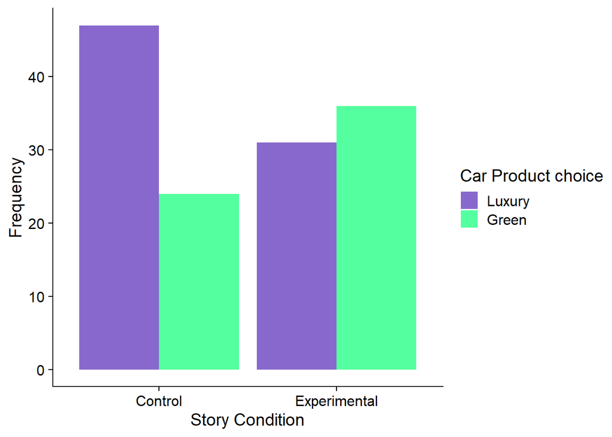

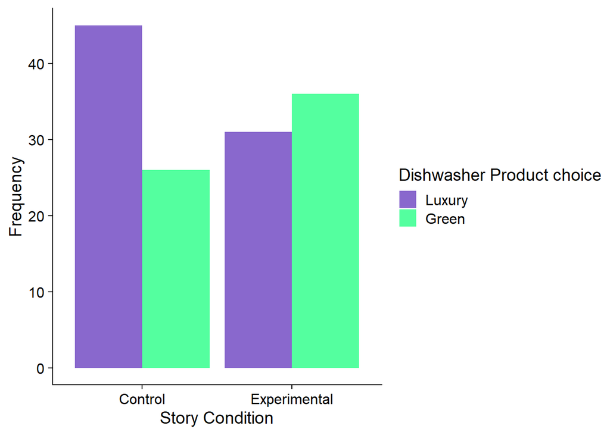

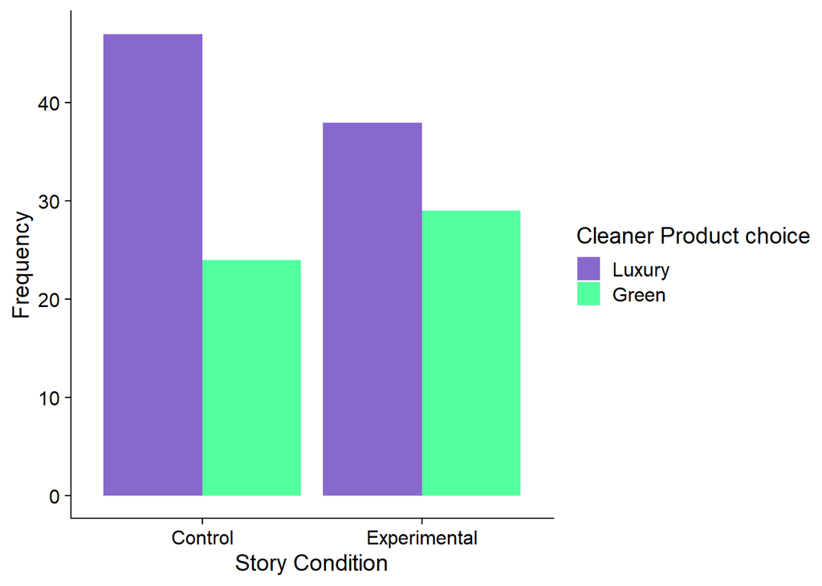

The figures above show a consistent pattern regarding the influence of status on product choice. With all products demonstrating a percentage increase from the control to the experemental condition. The car produced a percentage increase of 58.96%, thus producing a significant association. Where as the dishwasher condition had a percentage increase of 46.72%, a non-significant association. The cleaner condition also produced a non-significant association with a percentage increase of only 28.05%. Therfore showing that eventhough not all increases where significant, they did infact occur.

# Discussion

From the result, we can infer that some products may be more greatly affected by the influence of status than others. Participants exposed to the experimental condition are more likely to purchase a green car, but are not as likely to purchase a green cleaner or dishwasher. These findings do not align with the original study, since they found a significant association for all three products, not just one *(Griskevicius, Tybur and Van den Bergh, 2010)*. This variation of results implies that other factors and explanations may be need to be considered when investigating this topic.

Another replication which supports Griskevicius et al’s original study is that of Arianne J.van der Wal et al *(van der Wal, van Horen and Grinstein, 2016)*, who found that shoppers of sustainable stores displayed their sustainable shopping more, by using branded shopping bags than those who shopped at less sustainable stores. This aligns with the original study since it shows how perceived status has an effect on peoples sustainable shopping choices.

However, other studies into why people choose green products place more influence onto other variables. For example, a study by Ali et al *(Ali et al., 2019)* found that ‘materialism, vertical individualism, horizontal collectivism, and vertical collectivism’ help to maximise the effect of status motivation on a customer’s purchasing behaviour for a green-luxury car. This influence of collectivism or individualism is ignored by the original study and in turn our replication.

A limitation of both the original study and our replication, is that participants did not actually purchase the products proposed, they only did so hypothetically. This lack of ecological validity is likely to have affected the results of this study. Another limitation of both studies it that they both ignore the influence of financial factors on people’s decisions. A study by Hafer et al *(Hafner, Elmes, Read and White, 2019)* found that informing people of the financial benefits of green purchasing increased participants likelihood of choosing this product. These finding are relevant to our replication since a car is a much larger financial investment than a both a cleaner and a dishwasher. This underlying influence of a financial mind may be what lead to more people choosing the green car over the luxury one. Perhaps the participants used in the replication study are more financially conscious since they are on a student budget compared to those in the original study.

On the whole, Griskevicius et al’s original study and our replication ignores other, possibly crucial, factors which may contribute to people’s choice of product. Factors such as personality type and financial elements as well as external cultural factors, have been successfully researched within other studies, and have shown positive results.

Even though this replication has produced different findings than the original, they may both still be right. It could be inferred that as both studies neglected variables such as personality and cultural factors, differences arose due to potential experimental and theoretical errors. By simplifying the causes down to just the influence of status, this leaves room for variation in results between the replication and the original study.

# References

- Ali, A., Xiaoling, G., Ali, A., Sherwani, M. and Muneeb, F., 2019. Customer motivations for sustainable consumption: Investigating the drivers of purchase behavior for a green‐luxury car. *Business Strategy and the Environment*, 28(5), pp.833-846.
- Griskevicius, V., Tybur, J. and Van den Bergh, B., 2010. Going green to be seen: Status, reputation, and conspicuous conservation. *Journal of Personality and Social Psychology*, 98(3), pp.392-404.
- Hafner, B., Elmes, D., Read, D. and White, M., 2019. Exploring the role of normative, financial and environmental information in promoting uptake of energy efficient technologies. *Journal of Environmental Psychology*, 63, pp.26-35.
- van der Wal, A., van Horen, F. and Grinstein, A., 2016. The paradox of ‘green to be seen’: Green high-status shoppers excessively use (branded) shopping bags. *International Journal of Research in Marketing*, 33(1), pp.216-219.